# Discussion 1.1: Application of Time Series

U.S. Residential Building Permits (Top 5 States All-Time)

Jordan Blackman

2026-10-20

# Overview

This R Markdown document contains the data ingestion, `tsibble` construction, time series decomposition, and visualization for **Discussion 1.1: Application of Time Series**.

It analyzes monthly new privately-owned housing units authorized by building permits for the **top 5 states all-time** (Texas, Florida, California, North Carolina, and Georgia) using data from the U.S. Census Bureau via the Federal Reserve Bank of St. Louis (FRED).

# 1. Environment & Package Loading

We use the core `tidyverts` framework (`fpp3`), along with `tidyverse` and `readr`.

```r
library(tidyverse)
library(fpp3)
```

# 2. Data Ingestion from FRED

The Building Permits Survey (BPS) provides monthly, not seasonally adjusted (`NSA`) permit volumes from January 1988 to the present. The top 5 states by cumulative volume all-time are:

1. **Texas (TX)** – `TXBPPRIV`
2. **Florida (FL)** – `FLBPPRIV`
3. **California (CA)** – `CABPPRIV`
4. **North Carolina (NC)** – `NCBPPRIV`
5. **Georgia (GA)** – `GABPPRIV`

```r
top_states <- c(
  "Texas"          = "TXBPPRIV",
  "Florida"        = "FLBPPRIV",
  "California"     = "CABPPRIV",
  "North Carolina" = "NCBPPRIV",
  "Georgia"        = "GABPPRIV"
)

data_dir <- "data"
if (!dir.exists(data_dir)) dir.create(data_dir, recursive = TRUE)

state_data_list <- list()

for (st_name in names(top_states)) {
  ticker <- top_states[[st_name]]
  url <- sprintf("https://fred.stlouisfed.org/graph/fredgraph.csv?id=%s", ticker)
  dest_file <- file.path(data_dir, paste0(ticker, ".csv"))

  # Cache locally so knitting is fast and reproducible
  if (!file.exists(dest_file)) {
    download.file(url, dest_file, quiet = TRUE)
  }

  raw_df <- read_csv(dest_file, show_col_types = FALSE)
  names(raw_df) <- c("date", "permits")

  state_data_list[[st_name]] <- raw_df |>
    mutate(
      state = st_name,
      permits = as.numeric(permits)
    ) |>
    filter(!is.na(permits))
}
```

# 3. Tidy `tsibble` Construction

We convert raw calendar dates into `yearmonth` temporal indices and construct a keyed `tsibble` with `state` as the cross-sectional key.

```r
permits_top5_ts <- bind_rows(state_data_list) |>
  mutate(Month = yearmonth(date)) |>
  select(Month, state, permits) |>
  as_tsibble(index = Month, key = state)

# Display tsibble summary
permits_top5_ts
```

```
## # A tsibble: 2,320 x 3 [1M]
## # Key:       state [5]
##       Month state      permits
##       <mth> <chr>        <dbl>
##  1 1988 Jan California   13840
##  2 1988 Feb California   15857
##  3 1988 Mar California   21863
##  4 1988 Apr California   23003
##  5 1988 May California   21325
##  6 1988 Jun California   25993
##  7 1988 Jul California   19697
##  8 1988 Aug California   24146
##  9 1988 Sep California   18614
## 10 1988 Oct California   24274
## # ℹ 2,310 more rows
```

### Cumulative Summary Table

```r
permits_top5_ts |>
  as_tibble() |>
  group_by(state) |>
  summarize(
    total_permits = sum(permits, na.rm = TRUE),
    mean_monthly  = mean(permits, na.rm = TRUE),
    n_months      = n(),
    .groups = "drop"
  ) |>
  arrange(desc(total_permits)) |>
  knitr::kable(
    format.args = list(big.mark = ","),
    digits = 1,
    col.names = c("State", "Cumulative Permits", "Monthly Mean", "Months Tracked")
  )
```

| State | Cumulative Permits | Monthly Mean | Months Tracked |
| --- | --- | --- | --- |
| Texas | 5,673,957 | 12,228.4 | 464 |
| Florida | 5,391,235 | 11,619.0 | 464 |
| California | 4,532,698 | 9,768.7 | 464 |
| North Carolina | 2,597,109 | 5,597.2 | 464 |
| Georgia | 2,383,228 | 5,136.3 | 464 |

# 4. Time Series Visualization (Discussion Post Visual)

## 4.1 Comparative Multi-Line Plot

This chart plots the monthly permit volumes across all five states from 1988 to the present.

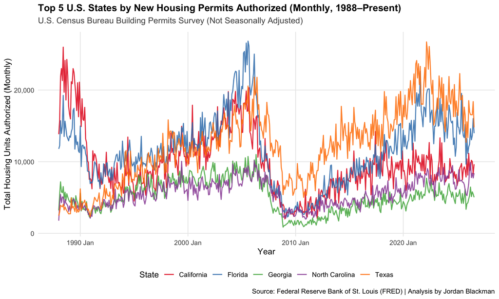

```r
p_comparison <- ggplot(permits_top5_ts, aes(x = Month, y = permits, color = state)) +
  geom_line(linewidth = 0.7, alpha = 0.85) +
  scale_y_continuous(labels = scales::comma) +
  scale_color_brewer(palette = "Set1") +
  labs(
    title = "Top 5 U.S. States by New Housing Permits Authorized (Monthly, 1988–Present)",
    subtitle = "U.S. Census Bureau Building Permits Survey (Not Seasonally Adjusted)",
    caption = "Source: Federal Reserve Bank of St. Louis (FRED) | Analysis by Jordan Blackman",
    x = "Year",
    y = "Total Housing Units Authorized (Monthly)",
    color = "State"
  ) +
  theme_minimal(base_size = 12) +
  theme(
    plot.title = element_text(face = "bold", size = 14),
    plot.subtitle = element_text(color = "gray30", margin = margin(b = 10)),
    legend.position = "bottom",
    panel.grid.minor = element_blank()
  )

p_comparison
```

## 4.2 Faceted Trajectories & Smoothed Trend-Cycles

Faceted individual panels with Loess smoothers highlight differences in underlying long-term growth and responses to macro shocks.

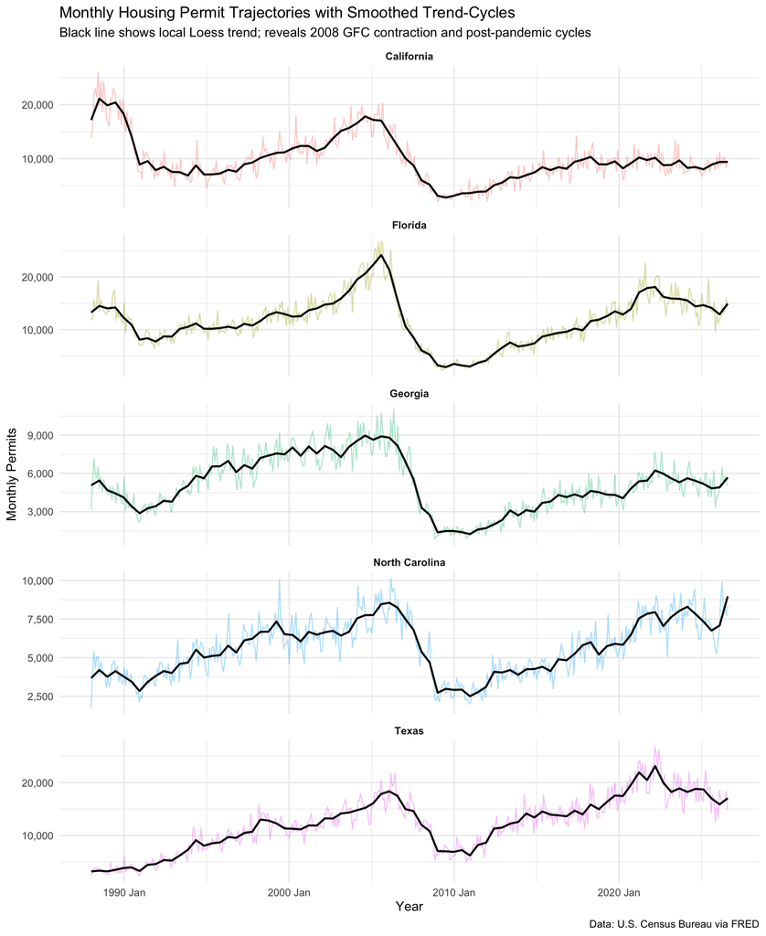

```r
p_faceted <- ggplot(permits_top5_ts, aes(x = Month, y = permits, color = state)) +
  geom_line(alpha = 0.35, linewidth = 0.45) +
  geom_smooth(method = "loess", span = 0.05, se = FALSE, color = "black", linewidth = 0.8) +
  facet_wrap(~ state, scales = "free_y", ncol = 1) +
  scale_y_continuous(labels = scales::comma) +
  labs(
    title = "Monthly Housing Permit Trajectories with Smoothed Trend-Cycles",
    subtitle = "Black line shows local Loess trend; reveals 2008 GFC contraction and post-pandemic cycles",
    x = "Year",
    y = "Monthly Permits",
    caption = "Data: U.S. Census Bureau via FRED"
  ) +
  theme_minimal(base_size = 11) +
  theme(
    legend.position = "none",
    strip.text = element_text(face = "bold")
  )

p_faceted
```

# 5. Component Analysis via STL Decomposition (Module 1 Concepts)

Connecting directly with Module 1’s focus on **STL Decomposition**, we decompose the #1 state (Texas) into its Trend, Seasonality, and Remainder noise components:

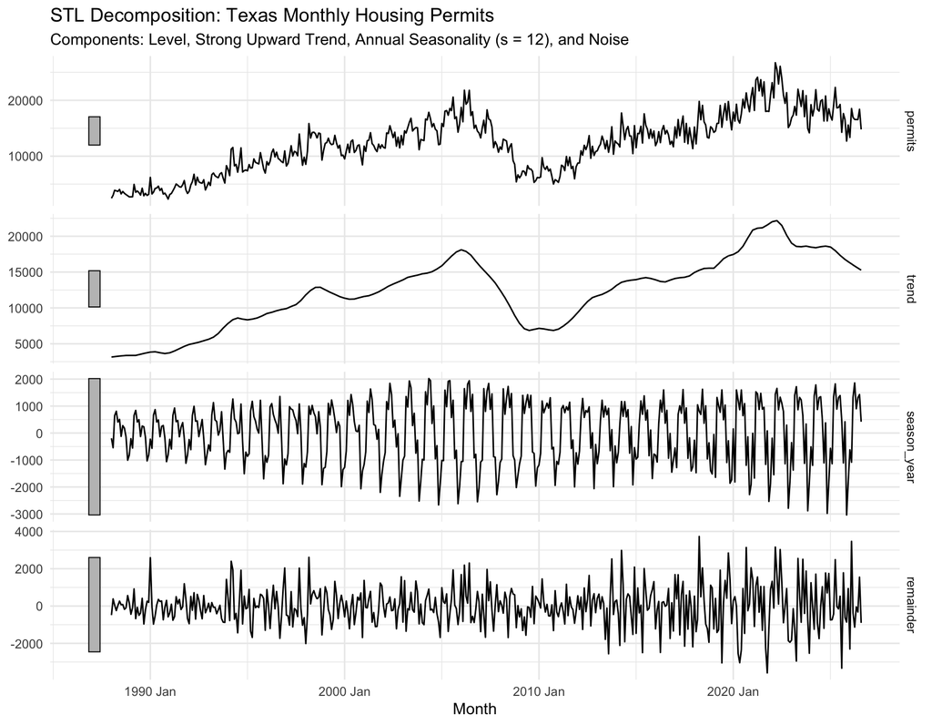

```r
p_stl_texas <- permits_top5_ts |>
  filter(state == "Texas") |>
  model(stl = STL(permits)) |>
  components() |>
  autoplot() +
  labs(
    title = "STL Decomposition: Texas Monthly Housing Permits",
    subtitle = "Components: Level, Strong Upward Trend, Annual Seasonality (s = 12), and Noise"
  ) +
  theme_minimal()

p_stl_texas
```

# 6. Empirical Diagnostics: Proving Annual Seasonality ($s = 12$)

In applied time-series analysis, $s$ (or $m$) denotes the **seasonal period**—the number of observations per cycle. Because this data is recorded monthly and repeats annually, $s = 12$. We confirm this structure below using three standard diagnostic techniques from `feasts`:

### 6.1 Seasonal Overlay Plot (`gg_season`)

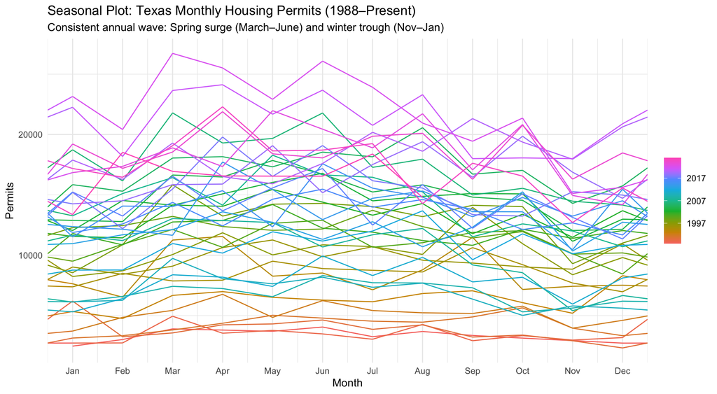

```r
permits_top5_ts |>
  filter(state == "Texas") |>
  gg_season(permits) +
  labs(
    title = "Seasonal Plot: Texas Monthly Housing Permits (1988–Present)",
    subtitle = "Consistent annual wave: Spring surge (March–June) and winter trough (Nov–Jan)",
    y = "Permits",
    x = "Month"
  ) +
  theme_minimal()
```

### 6.2 Seasonal Subseries Plot (`gg_subseries`)

The subseries plot groups the observations by individual calendar month across years. The blue horizontal line marks the historical mean for each month, showing that permit filing in April–June consistently exceeds winter volume by thousands of units.

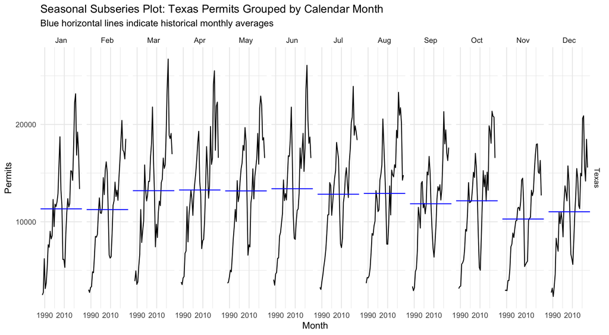

```r
permits_top5_ts |>
  filter(state == "Texas") |>
  gg_subseries(permits) +
  labs(
    title = "Seasonal Subseries Plot: Texas Permits Grouped by Calendar Month",
    subtitle = "Blue horizontal lines indicate historical monthly averages",
    y = "Permits",
    x = "Month"
  ) +
  theme_minimal()
```